# Analyzing Activity monitoring data

## What is the average daily activity pattern?

The average number of steps taken, averaged across all days :

```r
average_steps_per_interval = aggregate(steps ~ interval, data, mean)
steps_by_interval = average_steps_per_interval
```

Plot the Average Number of Steps per Day (y-axis) by Interval (x-axis)

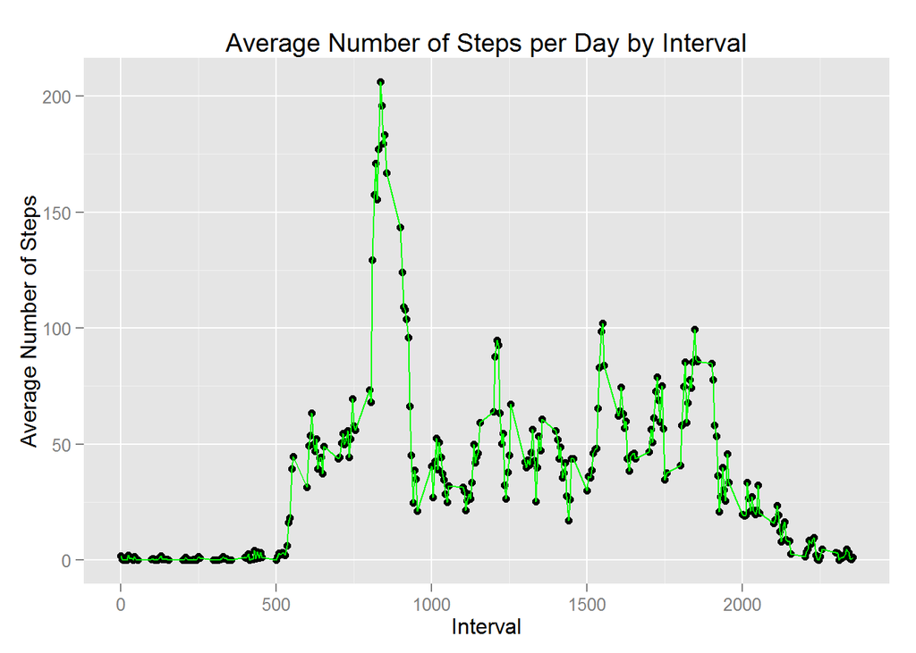

```r
library(ggplot2)
qplot(average_steps_per_interval$interval,average_steps_per_interval$steps, type="l", xlab="Interval", ylab="Average Number of Steps",main="Average Number of Steps per Day by Interval") + geom_line(colour = "green")
```

2. The 5-minute interval that contains the maximum number of steps on average, across all the days in the dataset

```r
maxSteps_interval = average_steps_per_interval[which.max(average_steps_per_interval$steps),1]
```

The 5-minute interval that contains the maximum number of steps on average, across all the days in the dataset is 835.

## Impute missing values. Compare imputed to non-imputed data.

1. Calculate and report the total number of missing values in the dataset (i.e. the total number of rows with NAs)

```r
nbOfNA <- sum(is.na(data$steps))
```

The total number of missing values is 2304

2. Filling in all of the missing values in the dataset. Using the mean for that 5-minute interval.

```r
filled_data <- transform(data, steps = ifelse(is.na(data$steps), average_steps_per_interval$steps[match(data$interval, average_steps_per_interval$interval)], data$steps))
```

3. Create a new dataset that is equal to the original dataset but with the missing data filled in.

NAs of the first day were assumed to be zeros to fit the rising trend of the data.

```r
filled_data[as.character(filled_data$date) == "2012-10-01", 1] <- 0
```

Recount total steps by day and create Histogram.

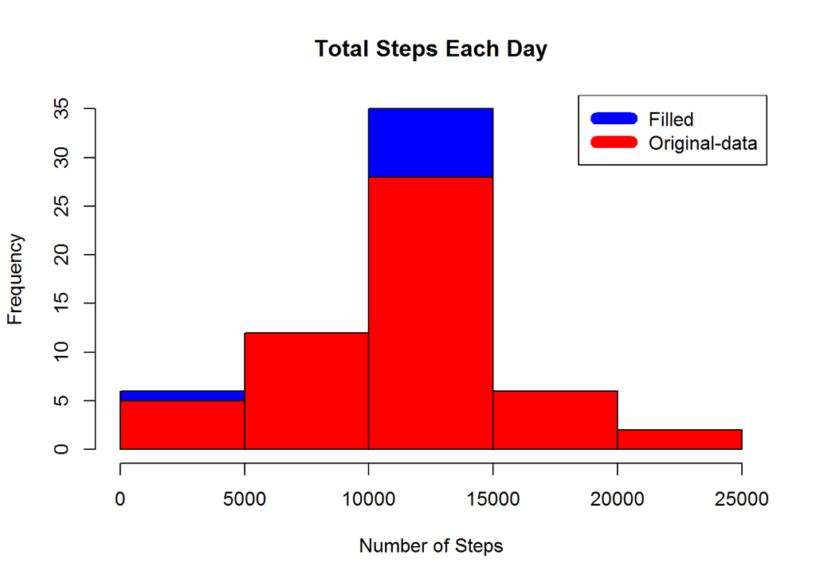

```r
steps_per_day_filled <- aggregate(steps ~ date, filled_data, sum)
hist(steps_per_day_filled$steps, main = paste("Total Steps Each Day"), col="blue", xlab="Number of Steps")

#Create Histogram to show difference.
hist(steps_per_day$steps, main = paste("Total Steps Each Day"), col="red", xlab="Number of Steps", add=T)
legend("topright", c("Filled", "Original-data"), col=c("blue", "red"), lwd=10)
```

Calculate new mean and median for filled data.

```r
meanSteps.filled   = mean  (steps_per_day_filled$steps)
medianSteps.filled = median(steps_per_day_filled$steps)
```

Calculate difference between filled and original (non-imputed) data.

```r
mean.diff    = meanSteps.filled   - meanSteps
median.diff  = medianSteps.filled - medianSteps
```

Calculate total difference.

```r
total.diff = sum(steps_per_day_filled$steps) - sum(steps_per_day$steps)
```

## Are there differences in activity patterns between weekdays and weekends?

1. Create a new factor variable in the dataset with two levels - “weekday” and “weekend” indicating whether a given date is a weekday or weekend day

```r
# french weekdays
weekdays <- c("lundi", "mardi", "mercredi", "jeudi", "vendredi")

#for english week days one's can set weekdays to
#weekdays <- c("Monday", "Tuesday", "Wednesday", "Thursday", "Friday")

filled_data$DayOfWeek = as.factor(ifelse(is.element(weekdays(as.Date(filled_data$date)),weekdays), "Weekday", "Weekend"))
```

2. A panel plot containing a time series plot (i.e. type = “l”) of the 5-minute interval (x-axis) and the average number of steps taken, averaged across all weekday days or weekend days (y-axis).

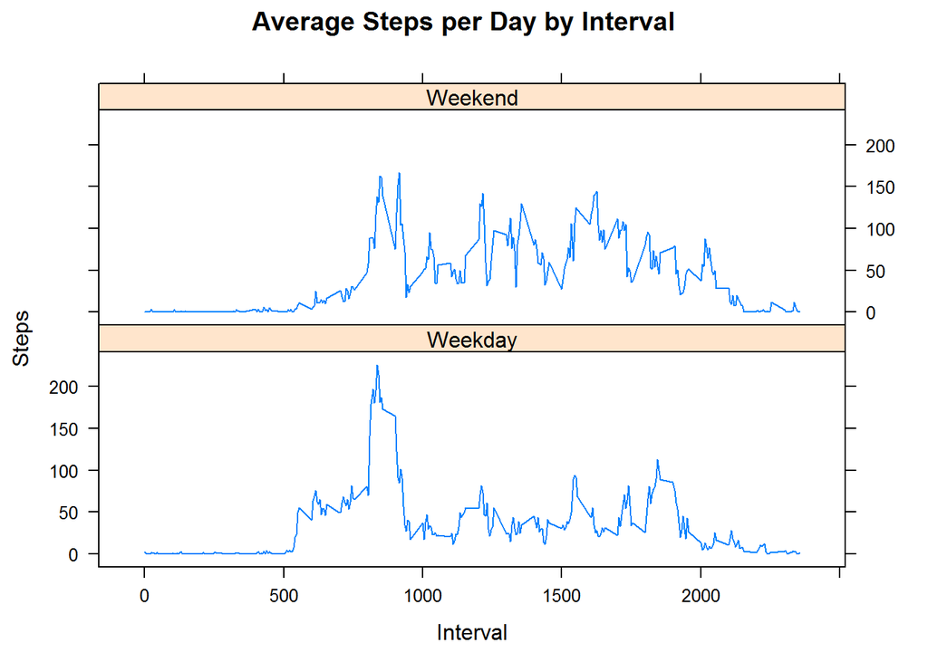

```r
steps_per_interval_filled = aggregate(steps ~ interval + DayOfWeek, filled_data, mean)
library(lattice)
xyplot(steps_per_interval_filled$steps ~ steps_per_interval_filled$interval | steps_per_interval_filled$DayOfWeek, main="Average Steps per Day by Interval",xlab="Interval", ylab="Steps",layout=c(1,2), type="l")
```